# Overdose Deaths EDA - Week 3 by Kyle Maher

### Packages

```r
library(tidyverse)
library(this.path)
library(readxl)
library(gt)
library(maps)
library(patchwork)
library(lubridate)
library(ggridges)
```

# Setup

### Overdose Data

- Remove columns with a constant value
  - “Period”
  - “Percent Complete”
- Coalesce “Predicted Value” and “Data Value”
- Rename to snake_case format

```r
raw_overdose <- read_csv(
  file.path(
    dirname(this.path()),
    "..",
    "data",
    "VSRR_Provisional_Drug_Overdose_Death_Counts.csv"
  )
)

overdose <- raw_overdose %>%
  mutate(value = coalesce(`Predicted Value`, `Data Value`)) %>%
  select(
    -Period,
    -"Percent Complete",
    -Footnote,
    -"Footnote Symbol",
    -"Predicted Value",
    -"Data Value"
  ) %>%
  rename(
    state_name = "State Name",
    state_abbreviation = State,
    year = Year,
    month = Month,
    indicator = Indicator,
    percent_pending_investigation = "Percent Pending Investigation"
  ) %>%
  mutate(
    month_year = my(paste(month, year)),
    state_name = as.factor(state_name),
    state_abbreviation = as.factor(state_abbreviation),
    year = as.integer(year),
    month = factor(month, levels = month.name, ordered = TRUE),
    indicator = as.factor(indicator),
    value = as.numeric(value),
    percent_pending_investigation = as.numeric(percent_pending_investigation)
  )
```

### Population Data

- Drop April 2021 estimates column
- Use pivot_longer() to transform the year into one column
- Remove the period before the state names

```r
raw_pop <- read_excel(
  file.path(
    dirname(this.path()),
    "..",
    "data",
    "NST-EST2024-POP.xlsx"
  ),
  range = "A4:G62"
)

# Drop estimates, pivot year columns together, remove regions, remove period.
pop <- raw_pop %>%
  rename(state_name = "...1", base_estimates_april_2021 = "...2") %>%
  select(-base_estimates_april_2021) %>%
  pivot_longer(
    cols = `2020`:`2024`,
    names_to = "year",
    values_to = "population"
  ) %>%
  mutate(state_name = sub("^\\.", "", state_name)) %>%
  mutate(year = as.integer(year))
```

### State Data (For Region)

- From the built in state.name and state.region
- Add the states that appear in the Population Data

```r
state <- data.frame(
  state_name = state.name,
  state_region = state.region
)

# Add states that appear in pop
odd_states <- data.frame(
  state_name =
    c("New York City",
      "District of Columbia",
      "Puerto Rico",
      "United States"),
  state_region =
    c("Northeast",
      "Northeast",
      NA,
      NA)
)

state <- bind_rows(state, odd_states)

state <- state %>%
  mutate(
    state_name = as.factor(state_name),
    state_region = as.factor(state_region)
  )
```

### Join Data Frames

```r
df <- overdose %>%
  left_join(pop, by = c("state_name", "year")) %>%
  left_join(state, by = "state_name") %>%
  mutate(state_name_lower = tolower(state_name))

df %>%
  select(month_year, state_name, state_region, population, indicator, value) %>%
  sample_n(10) %>%
  gt()
```

| month_year | state_name | state_region | population | indicator | value |
| --- | --- | --- | --- | --- | --- |
| 2024-11-01 | North Dakota | North Central | 796568 | Cocaine (T40.5) | NA |
| 2022-02-01 | Virginia | South | 8683414 | Cocaine (T40.5) | 755.00000 |
| 2016-11-01 | Missouri | North Central | NA | Natural, semi-synthetic, & synthetic opioids, incl. methadone (T40.2-T40.4) | NA |
| 2022-06-01 | New Jersey | Northeast | 9295227 | Natural & semi-synthetic opioids (T40.2) | 284.00000 |
| 2018-10-01 | Hawaii | West | NA | Number of Deaths | 11639.00000 |
| 2018-08-01 | Wisconsin | North Central | NA | Natural, semi-synthetic, & synthetic opioids, incl. methadone (T40.2-T40.4) | 711.00000 |
| 2023-12-01 | Missouri | North Central | 6208038 | Natural, semi-synthetic, & synthetic opioids, incl. methadone (T40.2-T40.4) | 1464.00000 |
| 2021-03-01 | Utah | West | 3339738 | Cocaine (T40.5) | 45.00000 |
| 2016-12-01 | District of Columbia | Northeast | NA | Percent with drugs specified | 99.33333 |
| 2017-06-01 | Delaware | South | NA | Opioids (T40.0-T40.4,T40.6) | NA |

# Investigate Counts

```r
df %>%
  select(month_year, state_region, indicator, value) %>%
  filter(!is.na(value)) %>%
  count(indicator, state_region) %>%
  arrange(desc(n)) %>%
  head(20) %>%
  gt() %>%
  data_color(
    columns = 3,
    direction = "column",
    fn = scales::col_numeric(
      palette = c("#F9F3EF", "#D2C1B6"),
      domain = NULL
    )
  )
```

| indicator | state_region | n |
| --- | --- | --- |
| Number of Deaths | South | 1968 |
| Number of Drug Overdose Deaths | South | 1968 |
| Percent with drugs specified | South | 1968 |
| Number of Deaths | West | 1599 |
| Number of Drug Overdose Deaths | West | 1599 |
| Percent with drugs specified | West | 1599 |
| Number of Deaths | North Central | 1476 |
| Number of Drug Overdose Deaths | North Central | 1476 |
| Percent with drugs specified | North Central | 1476 |
| Cocaine (T40.5) | South | 1417 |
| Natural & semi-synthetic opioids (T40.2) | South | 1417 |
| Natural & semi-synthetic opioids, incl. methadone (T40.2, T40.3) | South | 1417 |
| Natural, semi-synthetic, & synthetic opioids, incl. methadone (T40.2-T40.4) | South | 1417 |
| Opioids (T40.0-T40.4,T40.6) | South | 1417 |
| Synthetic opioids, excl. methadone (T40.4) | South | 1417 |
| Psychostimulants with abuse potential (T43.6) | South | 1413 |
| Methadone (T40.3) | South | 1359 |
| Number of Deaths | Northeast | 1353 |
| Number of Drug Overdose Deaths | Northeast | 1353 |
| Percent with drugs specified | Northeast | 1353 |

I’ll focus on “Number of Drug Overdose Deaths”

# Density Plot

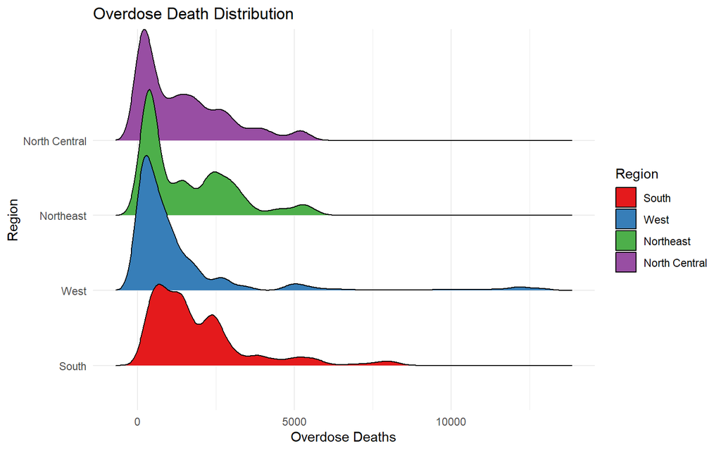

```r
df %>%
  filter(
    indicator == "Number of Drug Overdose Deaths",
    !is.na(state_region)
  ) %>%
  mutate(
    state_region = factor(
      state_region,
      levels = c("South", "West", "Northeast", "North Central")
    )
  ) %>%
  ggplot(aes(x = value, y = state_region, fill = state_region)) +
  ggridges::geom_density_ridges() +
  labs(
    x = "Overdose Deaths",
    y = "Region",
    title = "Overdose Death Distribution",
    fill = "Region"
  ) +
  scale_fill_brewer(palette = "Set1") +
  theme_minimal()
```

There appears to be a group of outliers for the West Region. Since the same outlier could appear in sum for twelve points, that may be a cause for the heavily skewed data here.

# Boxplot

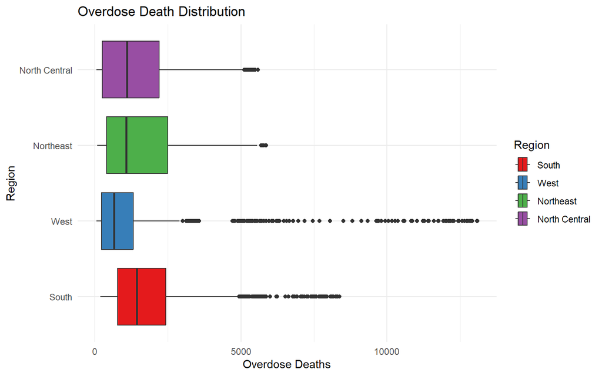

```r
df %>%
  filter(
    indicator == "Number of Drug Overdose Deaths",
    !is.na(state_region)
  ) %>%
  mutate(
    state_region = factor(
      state_region,
      levels = c("South", "West", "Northeast", "North Central")
    )
  ) %>%
  ggplot(aes(x = value, y = state_region, fill = state_region)) +
  geom_boxplot() +
  labs(
    x = "Overdose Deaths",
    y = "Region",
    title = "Overdose Death Distribution",
    fill = "Region"
  ) +
  scale_fill_brewer(palette = "Set1") +
  theme_minimal()
```

This makes those outliers more obvious.

# Overdose Deaths by Region

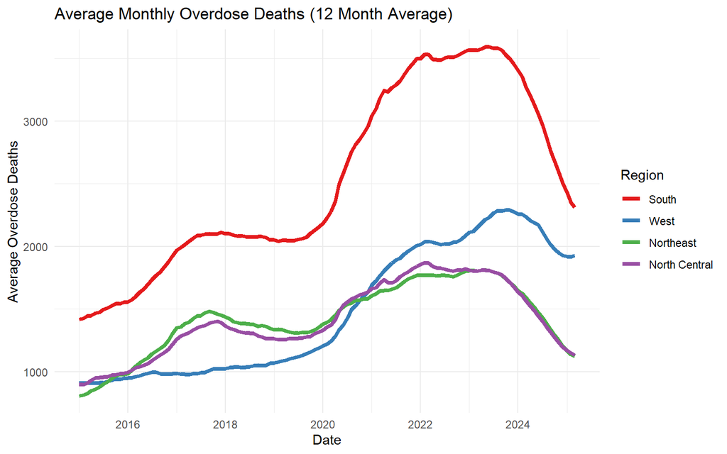

```r
df %>%
  filter(
    indicator == "Number of Drug Overdose Deaths",
    !is.na(state_region)
  ) %>%
  select(month_year, value, state_region, population) %>%
  group_by(state_region, month_year) %>%
  mutate(value = sum(value) / 12) %>%
  mutate(
    state_region = factor(
      state_region,
      levels = c("South", "West", "Northeast", "North Central")
    )
  ) %>%
  ggplot(aes(x = month_year, y = value, color = state_region)) +
  geom_line(linewidth = 1.5) +
  labs(
    x = "Date",
    y = "Average Overdose Deaths",
    title = "Average Monthly Overdose Deaths (12 Month Average)",
    color = "Region"
  ) +
  scale_color_brewer(palette = "Set1") +
  theme_minimal()
```

This is likley a more accurate representation than the distributions. The rolling average makes it more applicable to a line plot. Dividing by 12 gives the monthly average.

# Anova Test

```r
df_aov <- df %>%
  filter(indicator == "Number of Drug Overdose Deaths") %>%
  group_by(state_name, state_region) %>%
  summarise(
    mean_deaths = mean(value, na.rm = TRUE),  # average over months
    .groups = "drop"
  )

anova <- aov(mean_deaths ~ state_region, data = df_aov)

as.data.frame(summary(anova)[[1]]) %>%
  tibble::rownames_to_column("Source") %>%
  gt()
```

| Source | Df | Sum Sq | Mean Sq | F value | Pr(>F) |
| --- | --- | --- | --- | --- | --- |
| state_region | 3 | 2527825 | 842608.2 | 0.3161398 | 0.8136249 |
| Residuals | 48 | 127934516 | 2665302.4 | NA | NA |

The overall mean values don’t provide enough variation to show a statistically significant difference between the regions.

```r
df_aov <- df %>%
  filter(indicator == "Number of Drug Overdose Deaths")

anova <- aov(value ~ state_region, data = df_aov)

as.data.frame(summary(anova)[[1]]) %>%
  tibble::rownames_to_column("Source") %>%
  gt()
```

| Source | Df | Sum Sq | Mean Sq | F value | Pr(>F) |
| --- | --- | --- | --- | --- | --- |
| state_region | 3 | 310922440 | 103640813 | 35.54236 | 8.986054e-23 |
| Residuals | 6392 | 18638944721 | 2915980 | NA | NA |

However, when including all values the differences are definitely significant.

# State Map Plot

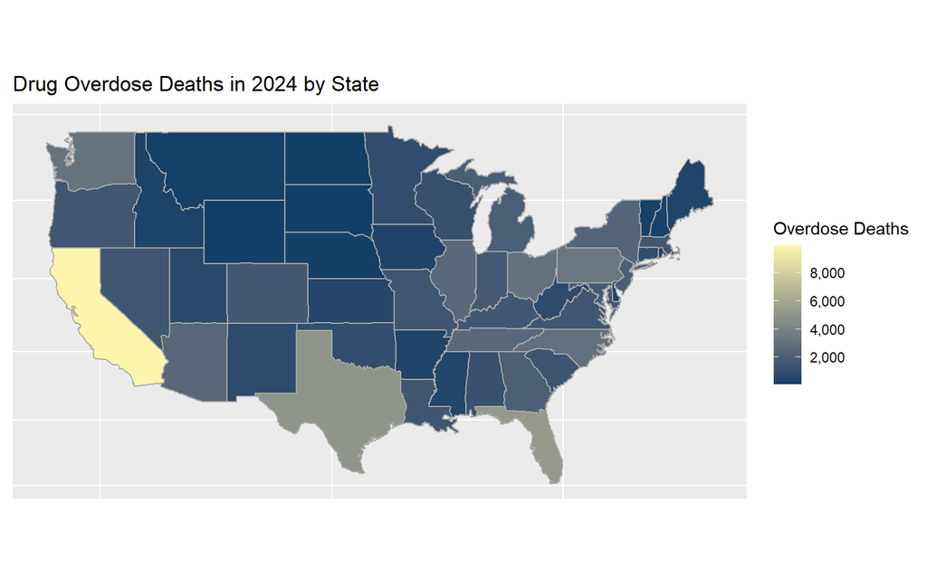

```r
state_lat_long <- map_data("state")

map <- df %>%
  filter(
    indicator == "Number of Drug Overdose Deaths",
    month_year == as.Date("2024-12-01"),
    !is.na(state_region)
  ) %>%
  group_by(state_name_lower) %>%
  summarise(value = value) %>%
  right_join(state_lat_long, by = c("state_name_lower" = "region"))

map <- map[order(map$order), ]

map %>% ggplot(aes(x = long, y = lat, group = group)) +
    geom_polygon(aes(fill = value), color = "darkgrey") +
    coord_map() +
    scale_fill_gradientn(
        colors = c("#113F67", "#FDF5AA"),
        labels = scales::comma,
        breaks = scales::pretty_breaks(n = 5)
    ) +
    labs(
        fill = "Overdose Deaths",
        title = "Drug Overdose Deaths in 2024 by State"
    ) +
    theme(
        axis.title = element_blank(),
        axis.ticks = element_blank(),
        axis.text = element_blank()
    )
```

Large states seem to have more deaths. Lets control for populaiton.

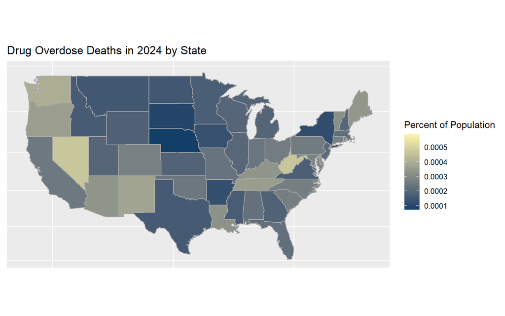

```r
state_lat_long <- map_data("state")

map <- df %>%
  filter(
    indicator == "Number of Drug Overdose Deaths",
    month_year == as.Date("2024-12-01"),
    !is.na(state_region)
  ) %>%
  group_by(state_name_lower) %>%
  summarise(value = value / population) %>%
  right_join(state_lat_long, by = c("state_name_lower" = "region"))

map <- map[order(map$order), ]

map %>% ggplot(aes(x = long, y = lat, group = group)) +
    geom_polygon(aes(fill = value), color = "darkgrey") +
    coord_map() +
    scale_fill_gradientn(
        colors = c("#113F67", "#FDF5AA"),
        labels = scales::comma,
        breaks = scales::pretty_breaks(n = 5)
    ) +
    labs(
        fill = "Percent of Population",
        title = "Drug Overdose Deaths in 2024 by State"
    ) +
    theme(
        axis.title = element_blank(),
        axis.ticks = element_blank(),
        axis.text = element_blank()
    )
```

Looks like Nevada and West Virginia have the highest percentage of Overdose Deaths by Population.

# Conclusion

The previous 12 month rolling sum removes any seasonality from the data which can make it easier to identify trends, but more difficult to do a quantitative analysis.

Nevada and West Virginia had the highest drug overdose rates in 2024 relative state populations.